# R Jam Sessions Vol. 1

Juan C. Sanchez-Arias

26/05/2020

## What is this? A website? A report? RStudio?

When we **Knit** an R Markdown (.rmd) it will generate a document that includes both content as well as the output of any embedded R code chunks within the document.

> Slack has a flavour of Markdown. You can also find Markdown on GitHub (GitHub flavour) and Reddit!

This an example: You can embed an R code chunk like this:

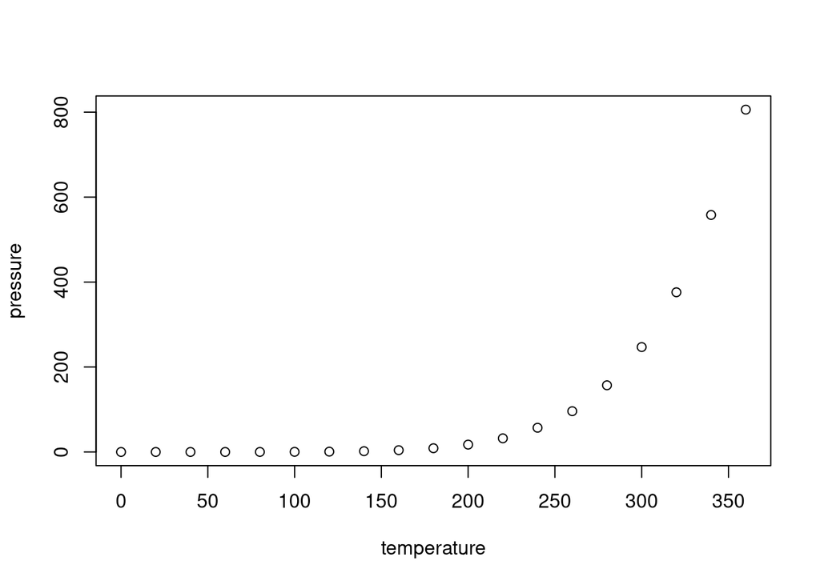

In the example above, the `echo = FALSE` parameter was added to the `` ```{r}``` `` code chunk to prevent printing of the R code `plot(pressure)` that generated the plot.

Let’s put that aside and start exploring some data!

## **Brain**span - Atlas of the Developing Human Brain

[**Brain**span](http://www.brainspan.org/static/home) contains a developmental transcriptome database.

[figure not shown]

From here, we can easily download normalized transcript levels throughout development in different brain regions.

Let’s check *PANX1* throughout development. Click [here](https://github.com/juansamdphd/rjam/tree/master/PANX1) to download the files.

## *PANX1* developmental profile

### Data exploration

Let’s import the files for *PANX1* and create a data.frame

```r
library(readr)
library(tidyverse)
PANX1_RNA <- t( # transposes the .csv
  read_csv("PANX1/Expression.csv", # reads the .csv file
           col_names = FALSE, # first row as values
           col_types = cols(X1 = col_skip()))  # removes the first row
)

PANX1_COL <- read_csv("PANX1/Columns.csv") # Imports Columns.csv

PANX1 <- data.frame(
  cbind(PANX1_COL,
        PANX1_log2_RPKM = PANX1_RNA)) # merges PANX1_COL & PANX1_RNA

rownames(PANX1) <- 1:nrow(PANX1) # gets row numbers
```

Let’s now check the first values and structure of `PANX1`

```r
head(PANX1) # prints first 6 observations in PANX1
```

```
##   donor_id  donor_name donor_age donor_color structure_id
## 1    13058 H376.IIA.51     8 pcw      0000FF        10173
## 2    13058 H376.IIA.51     8 pcw      0000FF        10185
## 3    13058 H376.IIA.51     8 pcw      0000FF        10278
## 4    13058 H376.IIA.51     8 pcw      0000FF        10194
## 5    13058 H376.IIA.51     8 pcw      0000FF        10291
## 6    13058 H376.IIA.51     8 pcw      0000FF        10208
##                                            structure_name
## 1                          dorsolateral prefrontal cortex
## 2                         ventrolateral prefrontal cortex
## 3 anterior (rostral) cingulate (medial prefrontal) cortex
## 4                                  orbital frontal cortex
## 5                  primary motor-sensory cortex (samples)
## 6                                      parietal neocortex
##   structure_abbreviation structure_color top_level_structure_id
```

[output cut: 20 more lines]

```r
str(PANX1) # prints `PANX1` structure
```

```
## 'data.frame':    524 obs. of  13 variables:
##  $ donor_id                        : num  13058 13058 13058 13058 13058 ...
##  $ donor_name                      : chr  "H376.IIA.51" "H376.IIA.51" "H376.IIA.51" "H376.IIA.51" ...
##  $ donor_age                       : chr  "8 pcw" "8 pcw" "8 pcw" "8 pcw" ...
##  $ donor_color                     : chr  "0000FF" "0000FF" "0000FF" "0000FF" ...
##  $ structure_id                    : num  10173 10185 10278 10194 10291 ...
##  $ structure_name                  : chr  "dorsolateral prefrontal cortex" "ventrolateral prefrontal cortex" "anterior (rostral) cingulate (medial prefrontal) cortex" "orbital frontal cortex" ...
##  $ structure_abbreviation          : chr  "DFC" "VFC" "MFC" "OFC" ...
##  $ structure_color                 : chr  "D4B235" "C2A335" "E26880" "E2D4A7" ...
##  $ top_level_structure_id          : num  10153 10153 10153 10153 10153 ...
##  $ top_level_structure_name        : chr  "neural plate" "neural plate" "neural plate" "neural plate" ...
##  $ top_level_structure_abbreviation: chr  "NP" "NP" "NP" "NP" ...
##  $ top_level_structure_color       : chr  "D7D8D8" "D7D8D8" "D7D8D8" "D7D8D8" ...
##  $ PANX1_log2_RPKM                 : num  4.66 4.99 4.97 4.41 4.69 ...
```

Let’s keep exploring the dataset and find out how many `unique` `donor_id` values are in `PANX1`. In other words let’s check the biological replicates.

```r
length(unique(PANX1$donor_id))
```

```
## [1] 42
```

Let’s group `PANX1` using `group_by` and `donor_id`.

*How many observations does each donor have?*

```r
PANX1 %>% group_by(donor_id) %>% count(sort = TRUE) %>% print(n=42)
```

```
## # A tibble: 42 x 2
## # Groups:   donor_id [42]
##     donor_id     n
##        <dbl> <int>
##  1     12288    16
##  2     12290    16
##  3     12302    16
##  4     12303    16
##  5     12830    16
##  6     12831    16
##  7     12832    16
##  8     12834    16
##  9     12837    16
## 10     12841    16
## 11     12890    16
```

[output cut: 31 more lines]

*How many observations from each strucutre and top level structure?*

> Hint: One plate to rule them all!

```r
PANX1 %>% group_by(structure_name, top_level_structure_name, top_level_structure_abbreviation) %>% count(sort = TRUE) %>% print(n = 26)
```

```
## # A tibble: 26 x 4
## # Groups:   structure_name, top_level_structure_name,
## #   top_level_structure_abbreviation [26]
##    structure_name               top_level_structure… top_level_structure_…     n
##    <chr>                        <chr>                <chr>                 <int>
##  1 posterior (caudal) superior… neural plate         NP                       36
##  2 dorsolateral prefrontal cor… neural plate         NP                       35
##  3 ventrolateral prefrontal co… neural plate         NP                       35
##  4 inferolateral temporal cort… neural plate         NP                       34
##  5 amygdaloid complex           neural plate         NP                       33
##  6 posteroventral (inferior) p… neural plate         NP                       33
##  7 primary visual cortex (stri… neural plate         NP                       33
##  8 anterior (rostral) cingulat… neural plate         NP                       32
##  9 hippocampus (hippocampal fo… allocortex           ACx                      32
## 10 orbital frontal cortex       neural plate         NP                       31
```

[output cut: 16 more lines]

```r
PANX1 %>% group_by(donor_id) %>% filter(top_level_structure_abbreviation == "NP") %>% count(sort = TRUE) %>% print(n=42)
```

```
## # A tibble: 42 x 2
## # Groups:   donor_id [42]
##     donor_id     n
##        <dbl> <int>
##  1     12288    13
##  2     12289    13
##  3     12290    13
##  4     12302    13
##  5     12303    13
##  6     12830    13
##  7     12831    13
##  8     12832    13
##  9     12834    13
## 10     12837    13
## 11     12841    13
```

[output cut: 31 more lines]

### Subsetting *PANX1* dataframe

So from the above analysis, structures derived from the neural plates are the most sampled by donor. Let’s subset `PANX1` and create a data frame with microarray data obtained from neural plate-derived structures (`top_level_structure_abbreviation == "NP"`)

```r
library(Rmisc) # Load Rmisc package
PANX1_NP <- PANX1 %>% # pipe `PANX1` into filter
  filter(top_level_structure_abbreviation == "NP") %>% # filter "NP" structures
  summarySE(measurevar = "PANX1_log2_RPKM",
            groupvars = c("donor_id", "donor_name", "donor_age"),
            na.rm = TRUE) %>% # get summary stats with Rmisc
  filter(N!=1) # filter out samples with N = 1 (producing NaNs)
```

Great! We have created `PANX1_NP` with *PANX1* transcript levels in neural plate strucutres and their summary statistics. We now have to deal with one more problem: `donor_age`. If you recall `str(PANX1)`, this variable type is `chr`.

Let’s use some of the some of the characters to our advantage and create prenatal (pcw) and postnatal (mos, yrs) dataframes.

```r
# Prenatal
PANX1_NP_pre <- PANX1_NP %>%
  filter(str_detect(donor_age, "pcw"))

PANX1_NP_pre <- PANX1_NP_pre %>%
  mutate(donor_age =
           as.numeric(gsub(" pcw", "", PANX1_NP_pre$donor_age))) %>%
  arrange(donor_age)

# Postnatal
PANX1_NP_post_mos <- PANX1_NP %>%
  filter(str_detect(donor_age, "mos"))

PANX1_NP_post_yrs <- PANX1_NP %>%
  filter(str_detect(donor_age, "yrs"))

# Convert months to years
PANX1_NP_post_mos <- PANX1_NP_post_mos %>%
  mutate(donor_age =
           (as.numeric(gsub(" mos", "", PANX1_NP_post_mos$donor_age)))/12) %>%
  arrange(donor_age)

# Remove yrs
PANX1_NP_post_yrs <- PANX1_NP_post_yrs %>%
  mutate(donor_age =
           (as.numeric(gsub(" yrs", "", PANX1_NP_post_yrs$donor_age)))) %>%
  arrange(donor_age)

PANX1_NP_post <- rbind(PANX1_NP_post_mos, PANX1_NP_post_yrs)
```

### Plotting time

We got in our hands now a nice “plottable” data frame. So, let’s plot!

#### *PANX1* prenatal

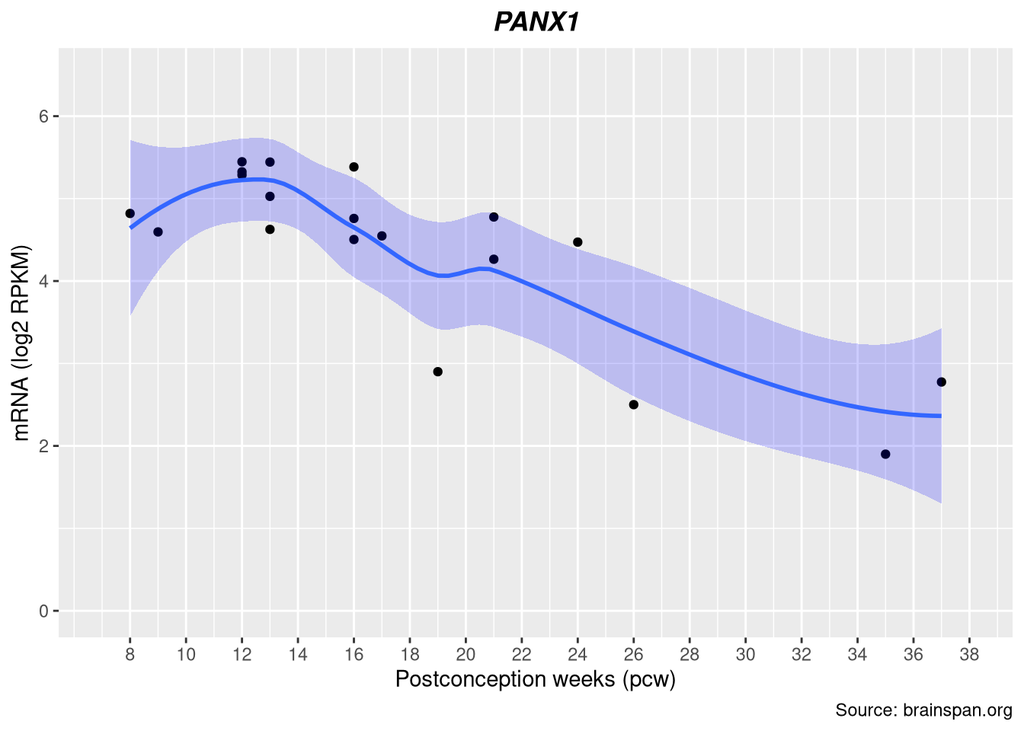

```r
PANX1_NP_pre %>%
  ggplot(aes(donor_age, PANX1_log2_RPKM)) +
  geom_point() +
  geom_smooth(fill = "blue", alpha = 0.2) + scale_x_continuous("Postconception weeks (pcw)",
                  limits = c(7,38),
                  breaks = seq(from = 8, to = 38, by = 2)) +
  ylab("mRNA (log2 RPKM)") +
  ggtitle("PANX1") +
  theme(plot.title = element_text(hjust = 0.5,
                                  face = "bold.italic")) +
  ylim(0,6.5) +
  labs(caption = "Source: brainspan.org")
```

#### *PANX1* postnatal

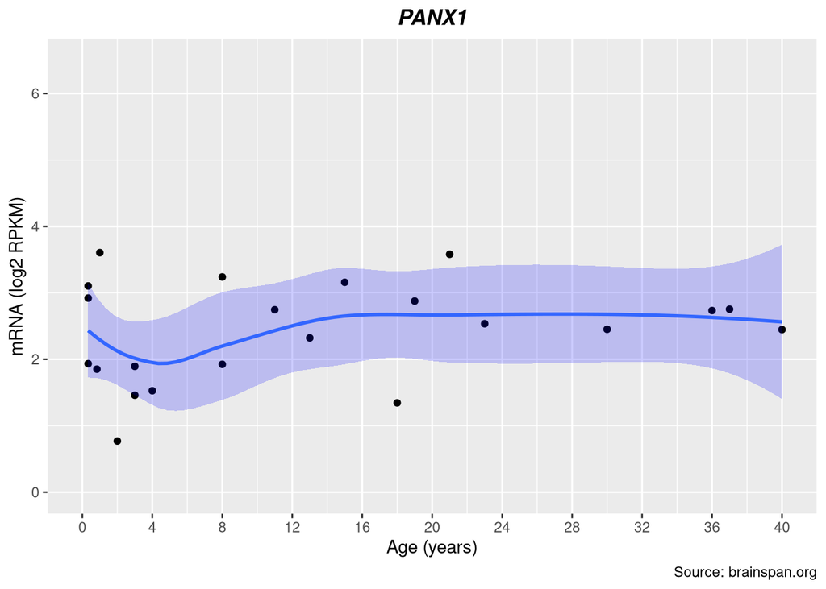

```r
PANX1_NP_post %>%
  ggplot(aes(donor_age, PANX1_log2_RPKM)) +
  geom_point() +
  geom_smooth(fill = "blue", alpha = 0.2) +
  scale_x_continuous("Age (years)", limits = c(0,40), breaks = seq(from = 0, to = 40, by = 4)) +
  ylab("mRNA (log2 RPKM)") +
  ggtitle("PANX1") +
  theme(plot.title = element_text(hjust = 0.5, face = "bold.italic")) +
  ylim(0,6.5) +
  labs(caption = "Source: brainspan.org")
```

## Some interesting facts

- Neural development starts at the 5th week of pma (3 pcw) with the development ofthe neural tube (Nakatsu et al., 2000).
- Neurogenesis starts at 6.5 pma (4.5 pcw), and continues throughout fetal devleopment up to 25-28 pma (23-26 pcw).
- At 24-26 pma (22-24 pcw) spontaneous activity transients (SATs) within cortical plate circuitscan be detected using EEG, starting focally in the somatosensory, auditory, and visual cortices (Vanhatalo et al., 2005; Vanhatalo and Kaila, 2006).
- With increasing age, SATs are longer, larger, and smaller in amplitude, becoming bilateral synchronous and organized in frontal and parieto-occipatal modules around term (Omidvarnia et al. 2014; Vanhatalo and Kaila, 2006).
- During the first term post birth, SATs drop and continuos synchronous acitivty becomes predominant in EEGs (Vanhatalo and Kaila, 2006; Andre et al., 2010; Eisermann et al., 2013).

## Outro

That’s all for today folks! You can use the above examples to explore levels of *PANX1* or your favourite gene in different brain regions, ages, etc.

> Stay tuned for Vol.2!